# Arline Arrivals

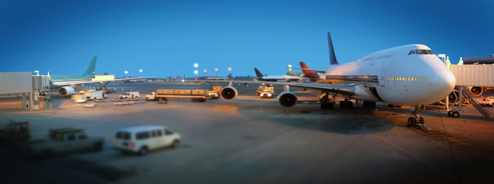

```python
from IPython.display import Image
Image("fl.jpg", width=1000, height=10, )
```

- Models included: Logistic Regression, Suport Vector Machine, Naive Bayes, Random Forest
- Feature Selections: SelectKBest, PCA

We apply each feature selection methods on each models to evaluate. Classify if flights arrive late, early or on time.

```python
import pandas as pd
import numpy as np
```

```python
data = pd.read_csv('data_num.csv')
```

```python
data.drop(columns=['Unnamed: 0'], inplace=True)
```

```python
pd.set_option('display.max_columns',None)
data.head().T
```

|  | 0 | 1 | 2 | 3 | 4 |
| --- | --- | --- | --- | --- | --- |
| Month | 1.0 | 1.0 | 1.0 | 1.0 | 1.0 |
| DayofMonth | 3.0 | 3.0 | 3.0 | 3.0 | 3.0 |
| DayOfWeek | 4.0 | 4.0 | 4.0 | 4.0 | 4.0 |
| ActualElapsedTime | 128.0 | 128.0 | 96.0 | 88.0 | 90.0 |
| CRSElapsedTime | 150.0 | 145.0 | 90.0 | 90.0 | 90.0 |
| AirTime | 116.0 | 113.0 | 76.0 | 78.0 | 77.0 |
| ArrDelay | -14.0 | 2.0 | 14.0 | -6.0 | 34.0 |
| DepDelay | 8.0 | 19.0 | 8.0 | -4.0 | 34.0 |
| Distance | 810.0 | 810.0 | 515.0 | 515.0 | 515.0 |
| TaxiIn | 4.0 | 5.0 | 3.0 | 3.0 | 3.0 |
| TaxiOut | 8.0 | 10.0 | 17.0 | 7.0 | 10.0 |
| Diverted | 0.0 | 0.0 | 0.0 | 0.0 | 0.0 |
| CarrierDelay | 0.0 | 0.0 | 0.0 | 0.0 | 2.0 |
| WeatherDelay | 0.0 | 0.0 | 0.0 | 0.0 | 0.0 |
| NASDelay | 0.0 | 0.0 | 0.0 | 0.0 | 0.0 |
| SecurityDelay | 0.0 | 0.0 | 0.0 | 0.0 | 0.0 |
| LateAircraftDelay | 0.0 | 0.0 | 0.0 | 0.0 | 32.0 |
| ArrivedLate | -1.0 | 0.0 | 0.0 | -1.0 | 1.0 |
| CRSDepTime_evening | 1.0 | 0.0 | 0.0 | 0.0 | 1.0 |
| CRSDepTime_morning | 0.0 | 1.0 | 1.0 | 0.0 | 0.0 |
| CRSDepTime_night | 0.0 | 0.0 | 0.0 | 0.0 | 0.0 |
| CRSDepTime_noon | 0.0 | 0.0 | 0.0 | 1.0 | 0.0 |
| CRSArrTime_evening | 0.0 | 0.0 | 0.0 | 0.0 | 1.0 |
| CRSArrTime_morning | 0.0 | 0.0 | 1.0 | 0.0 | 0.0 |
| CRSArrTime_night | 1.0 | 0.0 | 0.0 | 0.0 | 0.0 |
| CRSArrTime_noon | 0.0 | 1.0 | 0.0 | 1.0 | 0.0 |
| UniqueCarrier_9E | 0.0 | 0.0 | 0.0 | 0.0 | 0.0 |
| UniqueCarrier_AA | 0.0 | 0.0 | 0.0 | 0.0 | 0.0 |
| UniqueCarrier_AQ | 0.0 | 0.0 | 0.0 | 0.0 | 0.0 |
| UniqueCarrier_AS | 0.0 | 0.0 | 0.0 | 0.0 | 0.0 |
| UniqueCarrier_B6 | 0.0 | 0.0 | 0.0 | 0.0 | 0.0 |
| UniqueCarrier_CO | 0.0 | 0.0 | 0.0 | 0.0 | 0.0 |
| UniqueCarrier_DL | 0.0 | 0.0 | 0.0 | 0.0 | 0.0 |
| UniqueCarrier_EV | 0.0 | 0.0 | 0.0 | 0.0 | 0.0 |
| UniqueCarrier_F9 | 0.0 | 0.0 | 0.0 | 0.0 | 0.0 |
| UniqueCarrier_FL | 0.0 | 0.0 | 0.0 | 0.0 | 0.0 |
| UniqueCarrier_HA | 0.0 | 0.0 | 0.0 | 0.0 | 0.0 |
| UniqueCarrier_MQ | 0.0 | 0.0 | 0.0 | 0.0 | 0.0 |
| UniqueCarrier_NW | 0.0 | 0.0 | 0.0 | 0.0 | 0.0 |
| UniqueCarrier_OH | 0.0 | 0.0 | 0.0 | 0.0 | 0.0 |
| UniqueCarrier_OO | 0.0 | 0.0 | 0.0 | 0.0 | 0.0 |
| UniqueCarrier_UA | 0.0 | 0.0 | 0.0 | 0.0 | 0.0 |
| UniqueCarrier_US | 0.0 | 0.0 | 0.0 | 0.0 | 0.0 |
| UniqueCarrier_WN | 1.0 | 1.0 | 1.0 | 1.0 | 1.0 |
| UniqueCarrier_XE | 0.0 | 0.0 | 0.0 | 0.0 | 0.0 |
| UniqueCarrier_YV | 0.0 | 0.0 | 0.0 | 0.0 | 0.0 |

```python
data.shape
```

```
(6855029, 46)
```

Day la data sau khi da duoc clean va one-hot encode, voi 6.8M samples, 45 features va 1 target **ArrivedLate** da duoc tao them tu cot **ArrDelay** voi:

- **-1: early** chuyen bay dap som danh cho ArrDelay co value < 0
- **0: ok** chuyen bay dap dung gio danh cho ArrDelay co value < 30
- **1: late** chuyen bay dap tre danh cho ArrDelay co value >= 30

```python
data.describe(include='all').T
```

|  | count | mean | std | min | 25% | 50% | 75% | max |
| --- | --- | --- | --- | --- | --- | --- | --- | --- |
| Month | 6855029.0 | 6.388525 | 3.398833 | 1.0 | 3.0 | 6.0 | 9.0 | 12.0 |
| DayofMonth | 6855029.0 | 15.738258 | 8.801086 | 1.0 | 8.0 | 16.0 | 23.0 | 31.0 |
| DayOfWeek | 6855029.0 | 3.925802 | 1.988459 | 1.0 | 2.0 | 4.0 | 6.0 | 7.0 |
| ActualElapsedTime | 6855029.0 | 127.322424 | 70.187308 | 12.0 | 77.0 | 110.0 | 157.0 | 1379.0 |
| CRSElapsedTime | 6855029.0 | 129.077814 | 69.532711 | -141.0 | 80.0 | 111.0 | 159.0 | 660.0 |
| AirTime | 6855029.0 | 104.018589 | 67.439796 | 0.0 | 55.0 | 86.0 | 132.0 | 1350.0 |
| ArrDelay | 6855029.0 | 8.168452 | 38.501937 | -519.0 | -10.0 | -2.0 | 12.0 | 2461.0 |
| DepDelay | 6855029.0 | 9.923845 | 35.203863 | -534.0 | -4.0 | -1.0 | 8.0 | 2467.0 |
| Distance | 6855029.0 | 728.743834 | 563.244731 | 11.0 | 326.0 | 581.0 | 954.0 | 4962.0 |
| TaxiIn | 6855029.0 | 6.860150 | 4.931224 | 0.0 | 4.0 | 6.0 | 8.0 | 308.0 |
| TaxiOut | 6855029.0 | 16.443684 | 11.310621 | 0.0 | 10.0 | 14.0 | 19.0 | 429.0 |
| Diverted | 6855029.0 | 0.000000 | 0.000000 | 0.0 | 0.0 | 0.0 | 0.0 | 0.0 |
| CarrierDelay | 6855029.0 | 3.508113 | 20.016748 | 0.0 | 0.0 | 0.0 | 0.0 | 2436.0 |
| WeatherDelay | 6855029.0 | 0.675959 | 9.284375 | 0.0 | 0.0 | 0.0 | 0.0 | 1352.0 |
| NASDelay | 6855029.0 | 3.817854 | 16.650135 | 0.0 | 0.0 | 0.0 | 0.0 | 1357.0 |
| SecurityDelay | 6855029.0 | 0.016676 | 0.867370 | 0.0 | 0.0 | 0.0 | 0.0 | 392.0 |
| LateAircraftDelay | 6855029.0 | 4.620001 | 20.431506 | 0.0 | 0.0 | 0.0 | 0.0 | 1316.0 |
| ArrivedLate | 6855029.0 | -0.403090 | 0.714974 | -1.0 | -1.0 | -1.0 | 0.0 | 1.0 |
| CRSDepTime_evening | 6855029.0 | 0.343198 | 0.474777 | 0.0 | 0.0 | 0.0 | 1.0 | 1.0 |
| CRSDepTime_morning | 6855029.0 | 0.216886 | 0.412124 | 0.0 | 0.0 | 0.0 | 0.0 | 1.0 |
| CRSDepTime_night | 6855029.0 | 0.053790 | 0.225603 | 0.0 | 0.0 | 0.0 | 0.0 | 1.0 |
| CRSDepTime_noon | 6855029.0 | 0.386126 | 0.486860 | 0.0 | 0.0 | 0.0 | 1.0 | 1.0 |
| CRSArrTime_evening | 6855029.0 | 0.383571 | 0.486255 | 0.0 | 0.0 | 0.0 | 1.0 | 1.0 |
| CRSArrTime_morning | 6855029.0 | 0.100349 | 0.300465 | 0.0 | 0.0 | 0.0 | 0.0 | 1.0 |
| CRSArrTime_night | 6855029.0 | 0.141247 | 0.348276 | 0.0 | 0.0 | 0.0 | 0.0 | 1.0 |
| CRSArrTime_noon | 6855029.0 | 0.374833 | 0.484080 | 0.0 | 0.0 | 0.0 | 1.0 | 1.0 |
| UniqueCarrier_9E | 6855029.0 | 0.037100 | 0.189007 | 0.0 | 0.0 | 0.0 | 0.0 | 1.0 |
| UniqueCarrier_AA | 6855029.0 | 0.085410 | 0.279490 | 0.0 | 0.0 | 0.0 | 0.0 | 1.0 |
| UniqueCarrier_AQ | 6855029.0 | 0.001131 | 0.033609 | 0.0 | 0.0 | 0.0 | 0.0 | 1.0 |
| UniqueCarrier_AS | 6855029.0 | 0.021662 | 0.145577 | 0.0 | 0.0 | 0.0 | 0.0 | 1.0 |
| UniqueCarrier_B6 | 6855029.0 | 0.028025 | 0.165045 | 0.0 | 0.0 | 0.0 | 0.0 | 1.0 |
| UniqueCarrier_CO | 6855029.0 | 0.042867 | 0.202557 | 0.0 | 0.0 | 0.0 | 0.0 | 1.0 |
| UniqueCarrier_DL | 6855029.0 | 0.064760 | 0.246103 | 0.0 | 0.0 | 0.0 | 0.0 | 1.0 |
| UniqueCarrier_EV | 6855029.0 | 0.040097 | 0.196187 | 0.0 | 0.0 | 0.0 | 0.0 | 1.0 |
| UniqueCarrier_F9 | 6855029.0 | 0.013914 | 0.117136 | 0.0 | 0.0 | 0.0 | 0.0 | 1.0 |
| UniqueCarrier_FL | 6855029.0 | 0.037741 | 0.190568 | 0.0 | 0.0 | 0.0 | 0.0 | 1.0 |
| UniqueCarrier_HA | 6855029.0 | 0.008930 | 0.094073 | 0.0 | 0.0 | 0.0 | 0.0 | 1.0 |
| UniqueCarrier_MQ | 6855029.0 | 0.068732 | 0.252998 | 0.0 | 0.0 | 0.0 | 0.0 | 1.0 |
| UniqueCarrier_NW | 6855029.0 | 0.050198 | 0.218354 | 0.0 | 0.0 | 0.0 | 0.0 | 1.0 |
| UniqueCarrier_OH | 6855029.0 | 0.027818 | 0.164452 | 0.0 | 0.0 | 0.0 | 0.0 | 1.0 |
| UniqueCarrier_OO | 6855029.0 | 0.080731 | 0.272421 | 0.0 | 0.0 | 0.0 | 0.0 | 1.0 |
| UniqueCarrier_UA | 6855029.0 | 0.063892 | 0.244560 | 0.0 | 0.0 | 0.0 | 0.0 | 1.0 |
| UniqueCarrier_US | 6855029.0 | 0.065074 | 0.246657 | 0.0 | 0.0 | 0.0 | 0.0 | 1.0 |
| UniqueCarrier_WN | 6855029.0 | 0.173145 | 0.378372 | 0.0 | 0.0 | 0.0 | 0.0 | 1.0 |
| UniqueCarrier_XE | 6855029.0 | 0.053014 | 0.224062 | 0.0 | 0.0 | 0.0 | 0.0 | 1.0 |
| UniqueCarrier_YV | 6855029.0 | 0.035759 | 0.185689 | 0.0 | 0.0 | 0.0 | 0.0 | 1.0 |

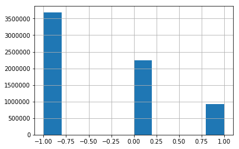

```python
data.ArrivedLate.hist()
```

Da so chuyen bay dap som, trong tap du lieu thi co khoang 1000000 chuyen bay dap tre. Day la class-imbalance, se duoc tune trong nhung model su dung.

```python
X = data.drop(columns=['ArrivedLate','ArrDelay'])
y = data['ArrivedLate']
```

```python
X.shape
```

```
(6855029, 44)
```

```python
from sklearn.preprocessing import MinMaxScaler
```

# Logistic Regression

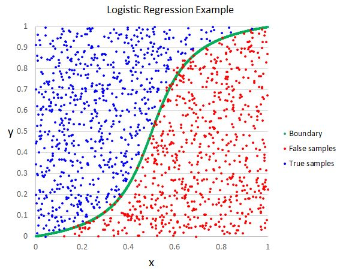

```python
Image("lr.jpg", width=500, height=10, )
```

```python
from sklearn.linear_model import LogisticRegression
from sklearn.feature_selection import SelectKBest, f_classif
from sklearn.model_selection import train_test_split
```

## SelectKBest

```python
selector = SelectKBest(f_classif, k=20)
selector.fit(X, y)
```

```
SelectKBest(k=20, score_func=<function f_classif at 0x000002822982FE18>)
```

```python
X_KB = selector.transform(X)
```

```python
X.columns[selector.get_support()]
```

```
Index(['Month', 'ActualElapsedTime', 'CRSElapsedTime', 'AirTime', 'DepDelay',
       'TaxiIn', 'TaxiOut', 'CarrierDelay', 'WeatherDelay', 'NASDelay',
       'LateAircraftDelay', 'CRSDepTime_evening', 'CRSDepTime_morning',
       'CRSArrTime_evening', 'CRSArrTime_morning', 'CRSArrTime_night',
       'CRSArrTime_noon', 'UniqueCarrier_AA', 'UniqueCarrier_US',
       'UniqueCarrier_WN'],
      dtype='object')
```

```python
y.value_counts(dropna=False)
```

```
-1    3690606
 0    2237008
 1     927415
Name: ArrivedLate, dtype: int64
```

Ro rang class dang unbalance, minh se them argument: class_weight de pass vao model:

```python
class_weight = {
    -1:36,
     0:22,
     1:9
}
```

```python
logreg = LogisticRegression(C=0.5,class_weight=class_weight)
```

```python
 X_train, X_test, y_train, y_test = train_test_split(X_KB, y, test_size=0.2, random_state=42)
```

```python
logreg.fit(X_train, y_train)
```

```
LogisticRegression(C=0.5, class_weight={-1: 36, 0: 22, 1: 9}, dual=False,
          fit_intercept=True, intercept_scaling=1, max_iter=100,
          multi_class='ovr', n_jobs=1, penalty='l2', random_state=None,
          solver='liblinear', tol=0.0001, verbose=0, warm_start=False)
```

```python
from sklearn.metrics import classification_report
y_pred = logreg.predict(X_test)
target_names = ['early', 'ok', 'late']
print(classification_report(y_test, y_pred, target_names=target_names))
```

```
             precision    recall  f1-score   support

      early       1.00      1.00      1.00    738394
         ok       1.00      1.00      1.00    447121
       late       1.00      0.99      1.00    185491

avg / total       1.00      1.00      1.00   1371006
```

Ket qua nhan duoc tren toan bo dataset la hoan hao sau khi tuning C va them argument class weight, toc do train rat nhanh

## PCA

```python
from sklearn.decomposition import PCA
pca = PCA(n_components=20)
pca.fit(X)
```

```
PCA(copy=True, iterated_power='auto', n_components=20, random_state=None,
  svd_solver='auto', tol=0.0, whiten=False)
```

```python
ratio = 0
for i, evr in enumerate(pca.explained_variance_ratio_):
    ratio += evr
    print('The first', i+1, ' features has the total evr of ', ratio)
```

```
The first 1  features has the total evr of  0.990112168547824
The first 2  features has the total evr of  0.9949600690234937
The first 3  features has the total evr of  0.99679253948584
The first 4  features has the total evr of  0.9979771494013592
The first 5  features has the total evr of  0.9987271496990234
The first 6  features has the total evr of  0.9990996753236123
The first 7  features has the total evr of  0.9994015554009098
The first 8  features has the total evr of  0.9996333239436785
The first 9  features has the total evr of  0.9998252209015964
The first 10  features has the total evr of  0.9999159449992525
The first 11  features has the total evr of  0.9999507193041143
The first 12  features has the total evr of  0.9999792926736886
The first 13  features has the total evr of  0.9999911120034942
The first 14  features has the total evr of  0.999993327284709
The first 15  features has the total evr of  0.9999950225450234
The first 16  features has the total evr of  0.9999960515452982
The first 17  features has the total evr of  0.9999966518982878
The first 18  features has the total evr of  0.9999970792788879
The first 19  features has the total evr of  0.999997476590671
The first 20  features has the total evr of  0.9999977164695457
```

O vector dau tien da the hien ratio rat tot, (99%), o day se lay 5 vectors.

```python
pca = PCA(n_components=5)
pca.fit(X)
```

```
PCA(copy=True, iterated_power='auto', n_components=5, random_state=None,
  svd_solver='auto', tol=0.0, whiten=False)
```

```python
X_PCA = pca.transform(X)
```

```python
X_PCA.shape
```

```
(6855029, 5)
```

```python
X_train, X_test, y_train, y_test = train_test_split(X_PCA, y, test_size=0.2, random_state=42)
```

```python
logreg = LogisticRegression(C=0.5,class_weight=class_weight)
logreg.fit(X_train, y_train)
y_pred = logreg.predict(X_test)
target_names = ['early', 'ok', 'late']
print(classification_report(y_test, y_pred, target_names=target_names))
```

```
             precision    recall  f1-score   support

      early       0.77      0.98      0.86    738394
         ok       0.88      0.50      0.64    447121
       late       0.94      0.92      0.93    185491

avg / total       0.83      0.81      0.80   1371006
```

Ket qua cung kha tot, tuy khong tot bang SelectKBest

# Support Vector Machine

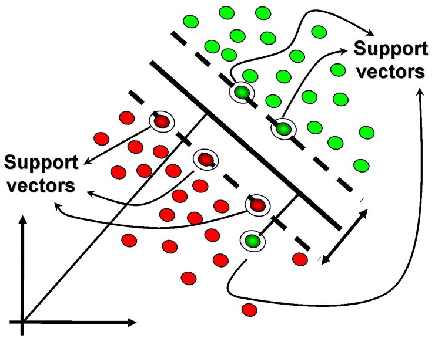

```python
Image("SVM.jpg", width=500, height=10, )
```

```python
from sklearn.svm import SVC
```

## SelectKBest

```python
X_KB = pd.DataFrame(X_KB)
data_KB = X_KB.join(y)
```

```python
data_KB.shape
```

```
(6855029, 21)
```

```python
data_KB_tune = data_KB.sample(100000)
```

```python
X_KB_tune = data_KB_tune.drop(columns=['ArrivedLate'])
y_KB_tune = data_KB_tune['ArrivedLate']
```

```python
y_KB_tune.value_counts(dropna=False)
```

```
-1    53886
 0    32604
 1    13510
Name: ArrivedLate, dtype: int64
```

```python
class_weight_KB_tune = {
    -1: 5,
     0: 3,
     1: 1
}
```

```python
X_train, X_test, y_train, y_test = train_test_split(X_KB_tune, y_KB_tune, test_size=0.2, random_state=42)
```

```python
svc = SVC(kernel='linear', C=2, class_weight=class_weight_KB_tune)
svc.fit(X_train, y_train)
y_pred = svc.predict(X_test)
target_names = ['early', 'ok', 'late']
print(classification_report(y_test, y_pred, target_names=target_names))
```

```
             precision    recall  f1-score   support

      early       1.00      1.00      1.00     10813
         ok       1.00      1.00      1.00      6493
       late       1.00      1.00      1.00      2694

avg / total       1.00      1.00      1.00     20000
```

Ket qua rat tot va chay rat nhanh voi sample nho, se dung de lam tren population tuy nhien SVM chay qua lau, da thu train = cac loai kernel khac nhung qua lau

## PCA

```python
X_PCA = pd.DataFrame(X_PCA)
data_PCA = X_PCA.join(y)
data_PCA.shape
```

```
(6855029, 6)
```

```python
data_PCA_tune = data_PCA.sample(10000)
X_PCA_tune = data_PCA_tune.drop(columns=['ArrivedLate'])
y_PCA_tune = data_PCA_tune['ArrivedLate']
y_KB_tune.value_counts(dropna=False)
```

```
-1    53886
 0    32604
 1    13510
Name: ArrivedLate, dtype: int64
```

```python
class_weight_PCA_tune = {
    -1: 5,
     0: 3,
     1: 1
}
```

```python
X_train, X_test, y_train, y_test = train_test_split(X_PCA_tune, y_PCA_tune, test_size=0.2, random_state=42)
```

```python
svc = SVC(kernel='linear', C=2, class_weight=class_weight_PCA_tune)
svc.fit(X_train, y_train)
y_pred = svc.predict(X_test)
target_names = ['early', 'ok', 'late']
print(classification_report(y_test, y_pred, target_names=target_names))
```

```
             precision    recall  f1-score   support

      early       0.81      0.95      0.88      1040
         ok       0.83      0.66      0.73       679
       late       0.99      0.85      0.92       281

avg / total       0.84      0.84      0.83      2000
```

Mot lan nua ket qua cung kha tot, nhung PCA van chua co performance tot bang SelectKBest nhu voi model Logistic Regression va train rat rat lau

# Naive Bayes

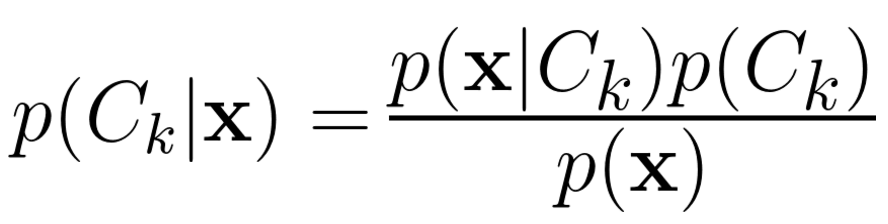

```python
Image("NB.png", width=500, height=10, )
```

## SelectKBest

```python
X_scaled = MinMaxScaler(feature_range=(0,100)).fit_transform(X)
```

Vi MultinomialNB() yeu cau input >= 0 nen phai scale lai X truoc roi su dung KBest de lua chon feature train

```python
selector = SelectKBest(f_classif, k=20)
selector.fit(X_scaled, y)
```

```
SelectKBest(k=20, score_func=<function f_classif at 0x0000021278E6F0D0>)
```

```python
X_scaled_KB = selector.transform(X_scaled)
```

```python
X_train, X_test, y_train, y_test = train_test_split(X_scaled_KB, y, test_size=0.2, random_state=42)
```

```python
class_prior = [0.54, 0.32, 0.14]
```

```python
from sklearn.naive_bayes import MultinomialNB
nb = MultinomialNB(alpha=0.00000001, class_prior=class_prior)
nb.fit(X_train, y_train)
y_pred = nb.predict(X_test)
target_names = ['early', 'ok', 'late']
print(classification_report(y_test, y_pred, target_names=target_names))
```

```
             precision    recall  f1-score   support

      early       0.70      0.52      0.60    738394
         ok       0.43      0.14      0.21    447121
       late       0.19      0.69      0.29    185491

avg / total       0.54      0.42      0.43   1371006
```

Da thu tune rat nhieu *alpha* va *class_prior* tuy nhien day la ket qua tot nhat dat duoc, model nay khong thich hop de lam cho du lieu nay.

## PCA

```python
pca = PCA(n_components=35)
pca.fit(X_scaled)
```

[output not shown]

```python
ratio = 0
for i, evr in enumerate(pca.explained_variance_ratio_):
    ratio += evr
    print('The first', i+1, ' features has the total evr of ', ratio)
```

[output not shown]

```python
pca = PCA(n_components=29)
pca.fit(X_scaled)
X_scaled_PCA = pca.transform(X_scaled)
```

```python
X_train, X_test, y_train, y_test = train_test_split(X_scaled_PCA, y, test_size=0.2, random_state=42)
nb = MultinomialNB()
nb.fit(X_train, y_train)
y_pred = nb.predict(X_test)
target_names = ['early', 'ok', 'late']
print(classification_report(y_test, y_pred, target_names=target_names))
```

do Model NB yeu cau X >= 0 nen ko the giam dimension = PCA

# Random Forest

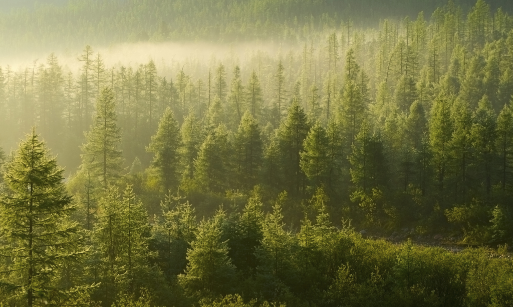

```python
from IPython.display import Image
Image("forests.jpg", width=500, height=10, )
```

## SelectKBest

```python
from sklearn.ensemble import RandomForestClassifier
```

```python
rf = RandomForestClassifier(n_estimators=15, max_depth=100,
                            min_samples_split=4, min_samples_leaf=3,
                            random_state=42, class_weight=class_weight)
```

```python
X_train, X_test, y_train, y_test = train_test_split(X_KB, y, test_size=0.2, random_state=42)
```

```python
rf.fit(X_train, y_train)
y_pred = rf.predict(X_test)
target_names = ['early', 'ok', 'late']
```

```python
print(classification_report(y_test, y_pred, target_names=target_names))
```

```
             precision    recall  f1-score   support

      early       0.93      0.98      0.96    738394
         ok       0.97      0.88      0.92    447121
       late       1.00      0.99      0.99    185491

avg / total       0.95      0.95      0.95   1371006
```

Ket qua dat duoc la rat tot, toc do train nhanh.

## PCA

```python
X_train, X_test, y_train, y_test = train_test_split(X_PCA, y, test_size=0.2, random_state=42)
rf = RandomForestClassifier(n_estimators=15, max_depth=100,
                            min_samples_split=4, min_samples_leaf=3,
                            random_state=42, class_weight=class_weight)
rf.fit(X_train, y_train)
y_pred = rf.predict(X_test)
target_names = ['early', 'ok', 'late']
print(classification_report(y_test, y_pred, target_names=target_names))
```

```
             precision    recall  f1-score   support

      early       0.88      0.93      0.90    738394
         ok       0.85      0.79      0.82    447121
       late       0.98      0.95      0.96    185491

avg / total       0.88      0.88      0.88   1371006
```

Ket qua dat duoc rat tot, tuy nhien mot lan nua PCA van khong tot bang SelectKBest

# Tuning GradientBoosting and RandomForest with GridSearchCV

```python
data_KB_cv = data_KB.sample(50000)
```

```python
from sklearn.model_selection import GridSearchCV
X_KB_cv = data_KB_cv.drop(columns=['ArrivedLate'])
y_KB_cv = data_KB_cv['ArrivedLate']
X_train, X_test, y_train, y_test = train_test_split(X_KB_cv, y_KB_cv, test_size=0.2, random_state=42)
parameters = {
    'n_estimators':[10, 20, 30, 40, 50],
    'max_depth':[50, 100, 150, 200],
    'min_samples_split':[5,10, 50, 100],
    'min_samples_leaf':[3,4, 10, 20],
             }
rf = RandomForestClassifier(random_state=42, class_weight=class_weight)
```

```python
clf = GridSearchCV(rf, parameters, scoring='f1_weighted')
```

```python
clf.fit(X_train, y_train)
```

```
GridSearchCV(cv=None, error_score='raise',
       estimator=RandomForestClassifier(bootstrap=True, class_weight={-1: 36, 0: 22, 1: 9},
            criterion='gini', max_depth=None, max_features='auto',
            max_leaf_nodes=None, min_impurity_decrease=0.0,
            min_impurity_split=None, min_samples_leaf=1,
            min_samples_split=2, min_weight_fraction_leaf=0.0,
            n_estimators=10, n_jobs=1, oob_score=False, random_state=42,
            verbose=0, warm_start=False),
       fit_params=None, iid=True, n_jobs=1,
       param_grid={'n_estimators': [10, 20, 30, 40, 50], 'max_depth': [50, 100, 150, 200], 'min_samples_split': [5, 10, 50, 100], 'min_samples_leaf': [3, 4, 10, 20]},
       pre_dispatch='2*n_jobs', refit=True, return_train_score='warn',
       scoring='f1_weighted', verbose=0)
```

# Conclusion on models

```python
y_pred = clf.predict(X_test)
target_names = ['early', 'ok', 'late']
print(classification_report(y_test, y_pred, target_names=target_names))
```

```
             precision    recall  f1-score   support

      early       0.83      0.95      0.89      5420
         ok       0.87      0.68      0.76      3222
       late       0.99      0.96      0.98      1358

avg / total       0.87      0.86      0.86     10000
```

```python
clf.best_estimator_
```

```
RandomForestClassifier(bootstrap=True, class_weight={-1: 36, 0: 22, 1: 9},
            criterion='gini', max_depth=50, max_features='auto',
            max_leaf_nodes=None, min_impurity_decrease=0.0,
            min_impurity_split=None, min_samples_leaf=3,
            min_samples_split=5, min_weight_fraction_leaf=0.0,
            n_estimators=40, n_jobs=1, oob_score=False, random_state=42,
            verbose=0, warm_start=False)
```

```python
clf.best_params_
```

```
{'max_depth': 50,
 'min_samples_leaf': 3,
 'min_samples_split': 5,
 'n_estimators': 40}
```

```python
rf = RandomForestClassifier(n_estimators=40, max_depth=50, min_samples_leaf=3, min_samples_split=5,
                            random_state=42, class_weight=class_weight)
X_train, X_test, y_train, y_test = train_test_split(X_KB, y, test_size=0.2, random_state=42)
rf.fit(X_train, y_train)
y_pred = rf.predict(X_test)
target_names = ['early', 'ok', 'late']
print(classification_report(y_test, y_pred, target_names=target_names))
```

```
             precision    recall  f1-score   support

      early       0.93      0.99      0.96    738394
         ok       0.97      0.88      0.92    447121
       late       1.00      0.99      1.00    185491

avg / total       0.95      0.95      0.95   1371006
```

# Gradient Boosting

```python
from sklearn.ensemble import GradientBoostingClassifier
```

```python
gb = GradientBoostingClassifier(loss='deviance', random_state=42, min_weight_fraction_leaf=.1, presort=True)
```

```python
parameters = {
    'learning_rate': [0.01, 0.03, 0.1],
    'n_estimators': [40, 100, 150],
    'max_depth': [50, 100],
    'min_samples_leaf': [1, 3, 5],
    'min_samples_split': [2, 5, 10],
    'min_impurity_decrease': [0, 0.5],
    'warm_start':[True, False]
}
```

```python
data_KB_cv = data_KB.sample(1500)
X_KB_cv = data_KB_cv.drop(columns=['ArrivedLate'])
y_KB_cv = data_KB_cv['ArrivedLate']
X_train, X_test, y_train, y_test = train_test_split(X_KB_cv, y_KB_cv, test_size=0.2, random_state=42)
```

```python
clf_gb = GridSearchCV(gb, parameters, scoring='f1_weighted')
```

```python
clf_gb.fit(X_train, y_train)
```

```
GridSearchCV(cv=None, error_score='raise',
       estimator=GradientBoostingClassifier(criterion='friedman_mse', init=None,
              learning_rate=0.1, loss='deviance', max_depth=3,
              max_features=None, max_leaf_nodes=None,
              min_impurity_decrease=0.0, min_impurity_split=None,
              min_samples_leaf=1, min_samples_split=2,
              min_weight_fraction_leaf=0.1, n_estimators=100, presort=True,
              random_state=42, subsample=1.0, verbose=0, warm_start=False),
       fit_params=None, iid=True, n_jobs=1,
       param_grid={'learning_rate': [0.01, 0.03, 0.1], 'n_estimators': [40, 100, 150], 'max_depth': [50, 100], 'min_samples_leaf': [1, 3, 5], 'min_samples_split': [2, 5, 10], 'min_impurity_decrease': [0, 0.5], 'warm_start': [True, False]},
       pre_dispatch='2*n_jobs', refit=True, return_train_score='warn',
       scoring='f1_weighted', verbose=0)
```

```python
clf_gb.best_params_
```

```
{'learning_rate': 0.1,
 'max_depth': 50,
 'min_impurity_decrease': 0,
 'min_samples_leaf': 1,
 'min_samples_split': 2,
 'n_estimators': 150,
 'warm_start': True}
```

```python
y_pred = clf_gb.predict(X_test)
target_names = ['early', 'ok', 'late']
print(classification_report(y_test, y_pred, target_names=target_names))
```

```
             precision    recall  f1-score   support

      early       0.84      0.94      0.89       162
         ok       0.83      0.58      0.69       103
       late       0.70      0.91      0.79        35

avg / total       0.82      0.82      0.81       300
```

```python
gb = GradientBoostingClassifier(loss='deviance',
                                random_state=42,
                                min_weight_fraction_leaf=.1,
                                presort=True,
                                learning_rate=0.1,
                                max_depth=50,
                                min_impurity_decrease=0,
                                min_samples_leaf=1,
                                min_samples_split=2,
                                n_estimators=150,
                                warm_start=True)
```

```python
X_train, X_test, y_train, y_test = train_test_split(X_KB, y, test_size=0.2, random_state=42)
gb.fit(X_train, y_train)
y_pred = rf.predict(X_test)
target_names = ['early', 'ok', 'late']
print(classification_report(y_test, y_pred, target_names=target_names))
```

```
             precision    recall  f1-score   support

      early       0.93      0.99      0.96    738394
         ok       0.97      0.88      0.92    447121
       late       1.00      0.99      1.00    185491

avg / total       0.95      0.95      0.95   1371006
```